# Explanatory Students' Academic Performance

## by Ahmed Fathi

## Investigation Overview

> Factors Affecting Success in School

## Dataset Overview

This is an educational data set which is collected from learning management system (LMS) called Kalboard 360. Kalboard 360 is a multi-agent LMS, which has been designed to facilitate learning through the use of leading-edge technology. Such system provides users with a synchronous access to educational resources from any device with Internet connection.  
The data is collected using a learner activity tracker tool, which called experience API (xAPI). The xAPI is a component of the training and learning architecture (TLA) that enables to monitor learning progress and learner’s actions like reading an article or watching a training video. The experience API helps the learning activity providers to determine the learner, activity and objects that describe a learning experience. The dataset consists of 480 student records and 16 features.

The features are classified into three major categories: 1) Demographic features such as gender and nationality.  
2) Academic background features such as educational stage, grade Level and section.  
3) Behavioral features such as raised hand on class, opening resources, answering survey by parents, and school satisfaction.

Form the violinplot the **fathers** view announcement **23 times** -approximately- in the mean, but the **mothers** view the announcement **50 time** in the mean... which is twice the mean of parents.

```
Father    283
Mum       197
Name: Relation, dtype: int64
```

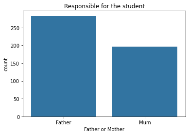

```python
# find the numbers each class in the dataset
print(performance.Relation.value_counts())

# visualize the Class column
sb.countplot(data = performance, x = "Relation", color = sb.color_palette()[0])
plt.title('Responsible for the student')
plt.xlabel('Father or Mother');
```

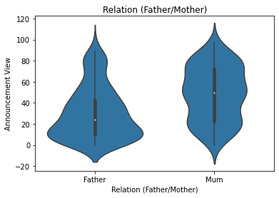

```python
# visualize the relationship between announcement view and relation(Responsible for the student from the parents)
sb.violinplot(data = performance, x = 'Relation' , y = 'AnnouncementsView', color = sb.color_palette()[0])

plt.title('Relation (Father/Mother)')
plt.xlabel('Relation (Father/Mother)')
plt.ylabel('Announcement View');
```

The heatmap show the stuednt absence under 7 days in the semester the parent is satisfied, and it is normal thing. on the other hand, when the student absence above 7 days in the semester the parent get bad, and also it is normal thing.  
But I wonder about the two section of "Bad & Under-7" and "Good & Above-7", So, I will visualize the heatmap one more time in the multivariate section in below... but I will add the 'Relation' column to the figure to get more understand about this point.

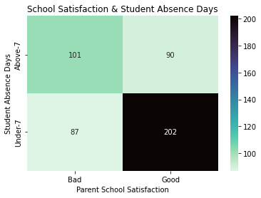

```python
# plot teh heatmap
sb.heatmap(parents_absence, annot = True, fmt = 'd', cmap = 'mako_r')

plt.title('School Satisfaction & Student Absence Days')
plt.xlabel('Parent School Satisfaction')
plt.ylabel('Student Absence Days');
```

From the visualization... The Relation which is resplsaple of parents (Father or Mother) affect on the state of the students which affects the parents’ evaluation of the school

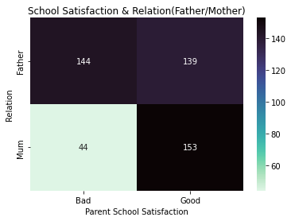

```python
# plot heatmap
sb.heatmap(parents_absence_relation, annot = True, fmt = 'd', cmap = 'mako_r')

plt.title('School Satisfaction & Relation(Father/Mother)')
plt.xlabel('Parent School Satisfaction')
plt.ylabel('Relation');
```

The absent days of the student affect on the satisfication of the parent about the school.

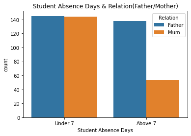

```python
# Visualze Student Absence Days and Relation
sb.countplot(data = performance, x ='StudentAbsenceDays', hue = 'Relation')

plt.title('Student Absence Days & Relation(Father/Mother)')
plt.xlabel('Student Absence Days');
```

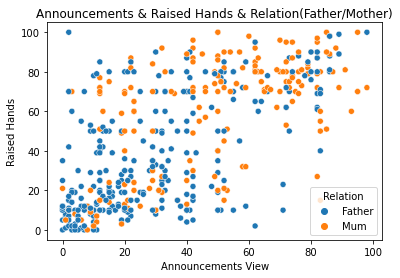

```python
sb.scatterplot(data = performance, x = 'AnnouncementsView', y = 'raisedhands', hue = 'Relation')

plt.title('Announcements & Raised Hands & Relation(Father/Mother)')
plt.xlabel('Announcements View')
plt.ylabel('Raised Hands');
```